# Coronavirus in Germany

D.H.K Wilathgamuwage

7/19/2020

# **INTRODUCTION**

### **Visualisation of the location**

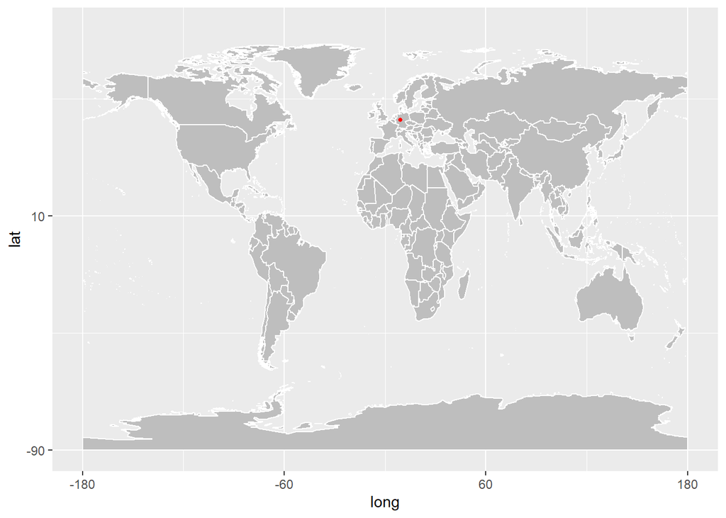

**Figure 01: Visualisation of the location - Germany**

Germany officially the Federal Republic of Germany is a country in central and western Europe, covering an area of 357,022 square kilometers. It borders Denmark to the north, Poland and the Czech Republic to east, Austria and Switzerland to the south and France, Belgium and the Netherlands to the west.Germany’s climate is moderate and has generally no longer periods of cold or hot weather. Northern western and Coastal Germany have a maritime influenced climate which is characterized by warm summer and mild cloudily winter.German states and the federal government have reached an agreement on more targeted measures to address localized outbreaks of Corona virus. One significant change is that entire districts will no longer be required to lockdown in the case of a localized outbreak, while quarantine and lockdown measures will be tightly limited to only targeted hotspots.Due to the Corona virus crisis the German government has reduced the threshold for the minimum number of employees who have to work short-time from 30% to 10%.Overall Global Health Security index of Germany is 66. Germany ranked at 14th among global health security capabilities in 195 countries.

# **EXPLORATORY DATA ANALYSIS**

```
      date              province           country               lat
 Min.   :2020-01-22   Length:336         Length:336         Min.   :51
 1st Qu.:2020-02-18   Class :character   Class :character   1st Qu.:51
 Median :2020-03-17   Mode  :character   Mode  :character   Median :51
 Mean   :2020-03-17                                         Mean   :51
 3rd Qu.:2020-04-14                                         3rd Qu.:51
 Max.   :2020-05-12                                         Max.   :51
      long       type               cases
 Min.   :9   Length:336         Min.   :  -31.0
 1st Qu.:9   Class :character   1st Qu.:    0.0
 Median :9   Mode  :character   Median :   35.5
 Mean   :9                      Mean   :  976.5
 3rd Qu.:9                      3rd Qu.: 1332.8
 Max.   :9                      Max.   :10219.0
```

**Table 01: Summary of Coronavirus data - Germany**

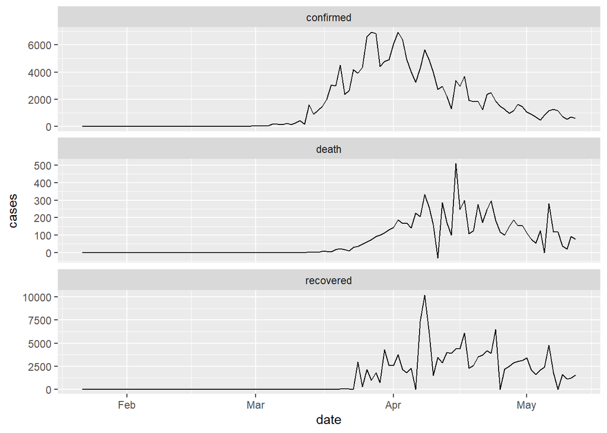

**Figure 02: Time series plot of Coronavirus spread in Germany**

```
      date              province           country               lat
 Min.   :2020-01-22   Length:112         Length:112         Min.   :51
 1st Qu.:2020-02-18   Class :character   Class :character   1st Qu.:51
 Median :2020-03-17   Mode  :character   Mode  :character   Median :51
 Mean   :2020-03-17                                         Mean   :51
 3rd Qu.:2020-04-14                                         3rd Qu.:51
 Max.   :2020-05-12                                         Max.   :51
      long       type               cases
 Min.   :9   Length:112         Min.   :   0.0
 1st Qu.:9   Class :character   1st Qu.:   1.0
 Median :9   Mode  :character   Median : 716.5
 Mean   :9                      Mean   :1546.2
 3rd Qu.:9                      3rd Qu.:2525.8
 Max.   :9                      Max.   :6933.0
```

**Table 02: Summary of confirmed cases data - Germany**

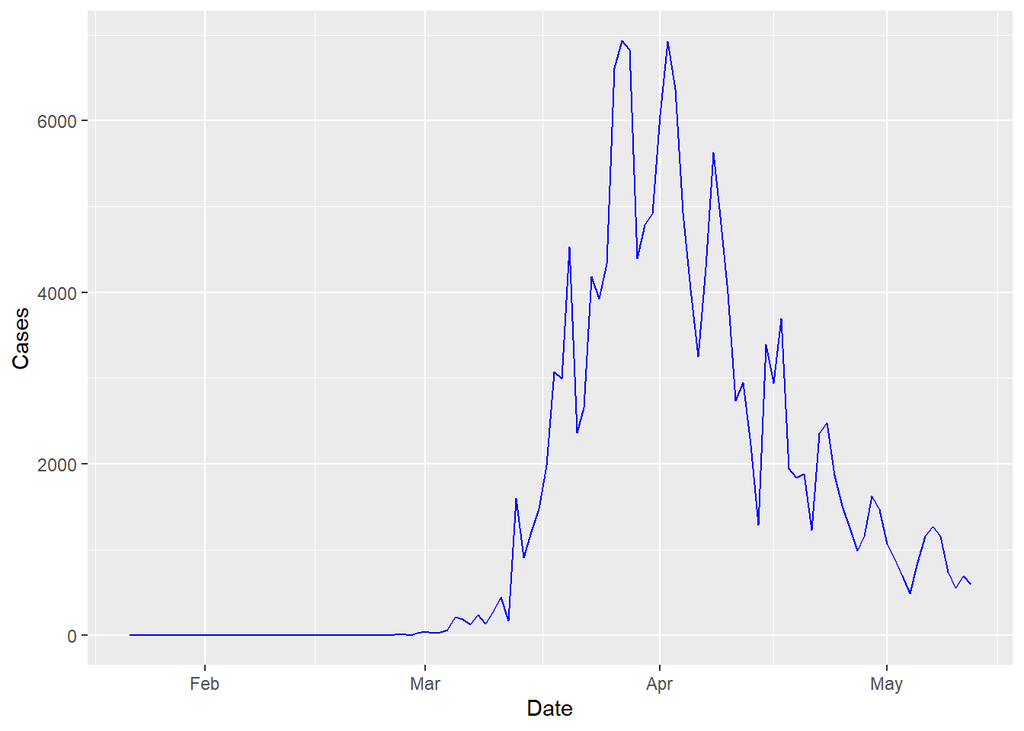

**Figure 03: Time series plot of Confirmed Cases in Germany.**

In **Figure 03**, Germany started out with a very high daily confirmed rate in March.Germany has managed to reduced it drastically within two months of coronavirus outbreak.

```
      date              province           country               lat
 Min.   :2020-01-22   Length:112         Length:112         Min.   :51
 1st Qu.:2020-02-18   Class :character   Class :character   1st Qu.:51
 Median :2020-03-17   Mode  :character   Mode  :character   Median :51
 Mean   :2020-03-17                                         Mean   :51
 3rd Qu.:2020-04-14                                         3rd Qu.:51
 Max.   :2020-05-12                                         Max.   :51
      long       type               cases
 Min.   :9   Length:112         Min.   :-31.00
 1st Qu.:9   Class :character   1st Qu.:  0.00
 Median :9   Mode  :character   Median :  4.00
 Mean   :9                      Mean   : 69.09
 3rd Qu.:9                      3rd Qu.:120.25
 Max.   :9                      Max.   :510.00
```

**Table 03: Summary of Death cases - Germany**

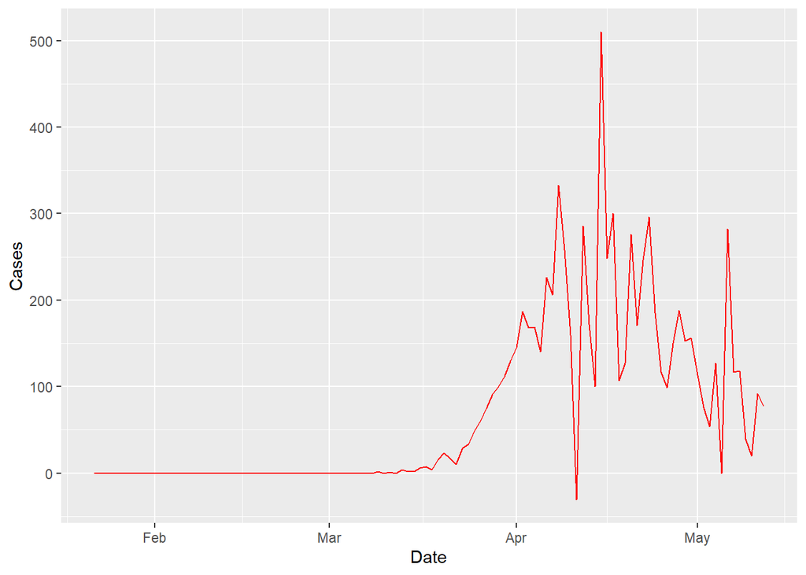

In **Figure 04**, Germany started out with a very low death rate. But from March onwards the number of deaths per day has increassd steadly. However from mid April onwards the number of deaths per day has reduced slighly.

```
      date              province           country               lat
 Min.   :2020-01-22   Length:112         Length:112         Min.   :51
 1st Qu.:2020-02-18   Class :character   Class :character   1st Qu.:51
 Median :2020-03-17   Mode  :character   Mode  :character   Median :51
 Mean   :2020-03-17                                         Mean   :51
 3rd Qu.:2020-04-14                                         3rd Qu.:51
 Max.   :2020-05-12                                         Max.   :51
      long       type               cases
 Min.   :9   Length:112         Min.   :    0.0
 1st Qu.:9   Class :character   1st Qu.:    0.0
 Median :9   Mode  :character   Median :    4.5
 Mean   :9                      Mean   : 1314.3
 3rd Qu.:9                      3rd Qu.: 2325.0
 Max.   :9                      Max.   :10219.0
```

**Table 04: Summary of Recovered cases data set- Germany(Including negetive values)**

[output not shown]

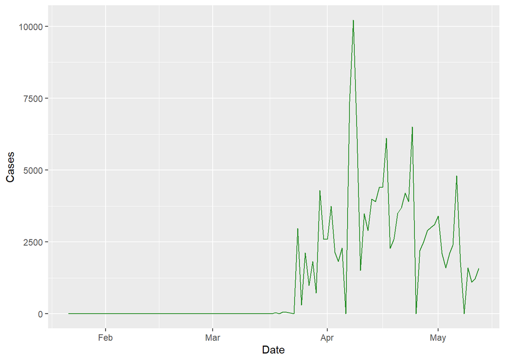

**Figure 05: Time series plot of Recovered Cases in Germany.**

In **Figure 05**, Initially the total recovered count per day in Germany was relatively low.However Germany has recorded the highest recovered patients per day in April and it was more than 10000 patients.

```
      date              confirmed          death          recovered
 Min.   :2020-01-22   Min.   :   0.0   Min.   :-31.00   Min.   :    0.0
 1st Qu.:2020-02-18   1st Qu.:   1.0   1st Qu.:  0.00   1st Qu.:    0.0
 Median :2020-03-17   Median : 716.5   Median :  4.00   Median :    4.5
 Mean   :2020-03-17   Mean   :1546.2   Mean   : 69.09   Mean   : 1314.3
 3rd Qu.:2020-04-14   3rd Qu.:2525.8   3rd Qu.:120.25   3rd Qu.: 2325.0
 Max.   :2020-05-12   Max.   :6933.0   Max.   :510.00   Max.   :10219.0
     active
 Min.   :-4919.0
 1st Qu.: -666.5
 Median :    0.0
 Mean   :  162.8
 3rd Qu.:  402.5
 Max.   : 5873.0
```

**Table 06: Summary of Active cases data - Germany(Including negetive values)**

```
      date              confirmed          death          recovered
 Min.   :2020-01-22   Min.   :   0.0   Min.   :-31.00   Min.   :    0.0
 1st Qu.:2020-02-18   1st Qu.:   1.0   1st Qu.:  0.00   1st Qu.:    0.0
 Median :2020-03-17   Median : 716.5   Median :  4.00   Median :    4.5
 Mean   :2020-03-17   Mean   :1546.2   Mean   : 69.09   Mean   : 1314.3
 3rd Qu.:2020-04-14   3rd Qu.:2525.8   3rd Qu.:120.25   3rd Qu.: 2325.0
 Max.   :2020-05-12   Max.   :6933.0   Max.   :510.00   Max.   :10219.0

     active
 Min.   :   0
 1st Qu.:   0
 Median :  44
 Mean   :1022
 3rd Qu.:1688
 Max.   :5873
 NA's   :36
```

**Table 07: Summary of Active cases data - Germany(Excluding negetive values)**

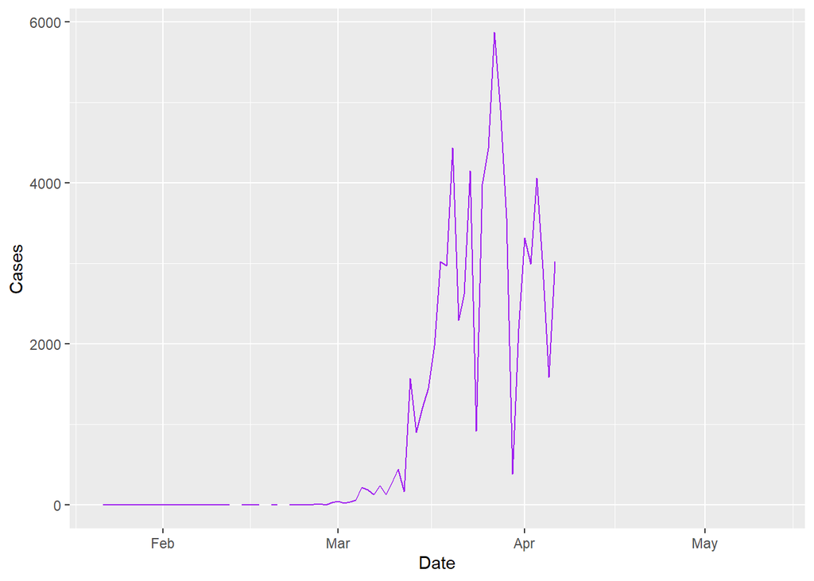

**Figure 06: Time series plot of Active Cases in Germany (Discontinuity represents missing values/ negative values)**

### Since Austria is a neighbouring country of Germany, Let’s look at Conoravirus spread in Austria.

## **AUSTRIA**

```
      date              province           country               lat
 Min.   :2020-01-22   Length:336         Length:336         Min.   :47.52
 1st Qu.:2020-02-18   Class :character   Class :character   1st Qu.:47.52
 Median :2020-03-17   Mode  :character   Mode  :character   Median :47.52
 Mean   :2020-03-17                                         Mean   :47.52
 3rd Qu.:2020-04-14                                         3rd Qu.:47.52
 Max.   :2020-05-12                                         Max.   :47.52
      long           type               cases
 Min.   :14.55   Length:336         Min.   :  -5.00
 1st Qu.:14.55   Class :character   1st Qu.:   0.00
 Median :14.55   Mode  :character   Median :   2.00
 Mean   :14.55                      Mean   :  91.46
 3rd Qu.:14.55                      3rd Qu.:  77.00
 Max.   :14.55                      Max.   :1321.00
```

**Table 08: Summary of Coronavirus data - Austria**

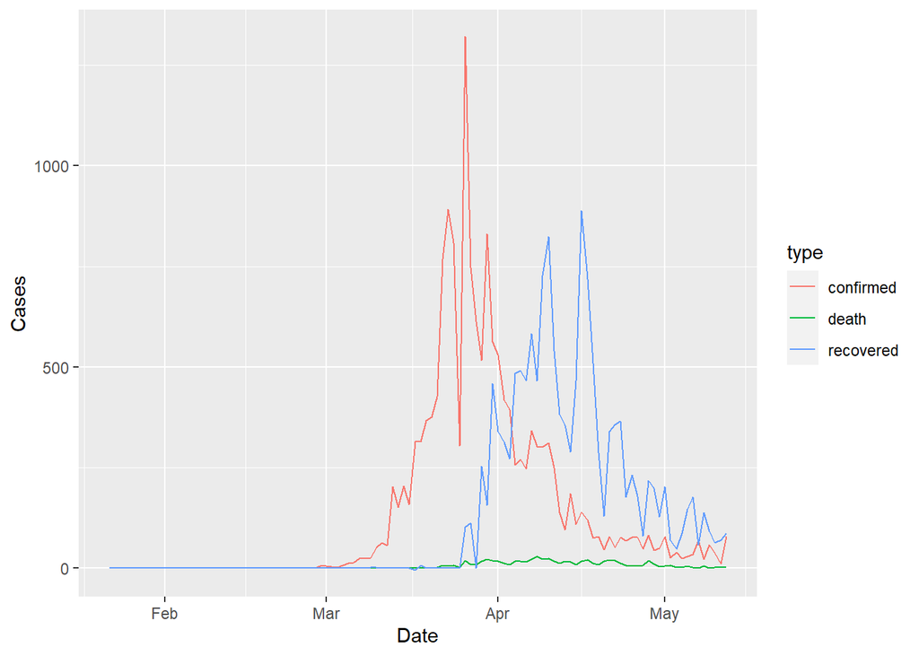

**Figure 07.1: Time series plot of Coronavirus spread in Austria**

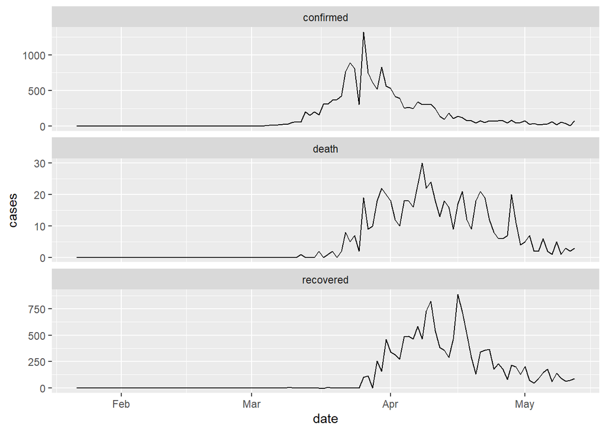

**Figure 07.2: Time series plot of Coronavirus spread in Austria**

```
      date              confirmed          death          recovered
 Min.   :2020-01-22   Min.   :   0.0   Min.   : 0.000   Min.   : -5.0
 1st Qu.:2020-02-18   1st Qu.:   0.0   1st Qu.: 0.000   1st Qu.:  0.0
 Median :2020-03-17   Median :  42.0   Median : 1.000   Median :  0.0
 Mean   :2020-03-17   Mean   : 142.5   Mean   : 5.562   Mean   :126.3
 3rd Qu.:2020-04-14   3rd Qu.: 189.2   3rd Qu.: 9.250   3rd Qu.:184.0
 Max.   :2020-05-12   Max.   :1321.0   Max.   :30.000   Max.   :888.0
     active
 Min.   :-765.00
 1st Qu.:-103.50
 Median :   0.00
 Mean   :  10.62
 3rd Qu.:  16.50
 Max.   :1199.00
```

```
      date              confirmed          death          recovered
 Min.   :2020-01-22   Min.   :   0.0   Min.   : 0.000   Min.   : -5.0
 1st Qu.:2020-02-18   1st Qu.:   0.0   1st Qu.: 0.000   1st Qu.:  0.0
 Median :2020-03-17   Median :  42.0   Median : 1.000   Median :  0.0
 Mean   :2020-03-17   Mean   : 142.5   Mean   : 5.562   Mean   :126.3
 3rd Qu.:2020-04-14   3rd Qu.: 189.2   3rd Qu.: 9.250   3rd Qu.:184.0
 Max.   :2020-05-12   Max.   :1321.0   Max.   :30.000   Max.   :888.0

     active
 Min.   :   0.0
 1st Qu.:   0.0
 Median :   1.5
 Mean   : 126.2
 3rd Qu.: 141.2
 Max.   :1199.0
 NA's   :38
```

**Table 11: Summary of Active cases data - Austria(Excluding negetive values)**

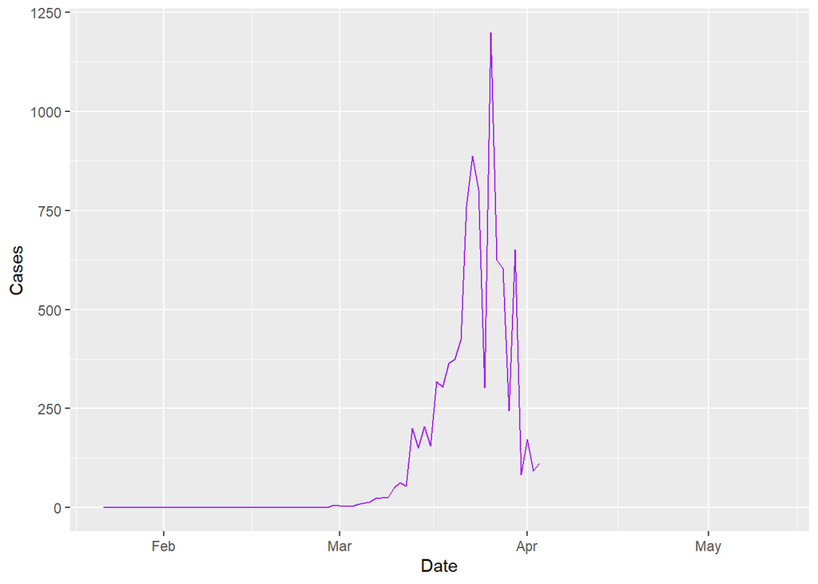

**Figure 08: Time series plot of Active Cases in Austria (Discontinuity represents missing values/ negative values)**

### Comparing Corona spread- Germany vs Austria

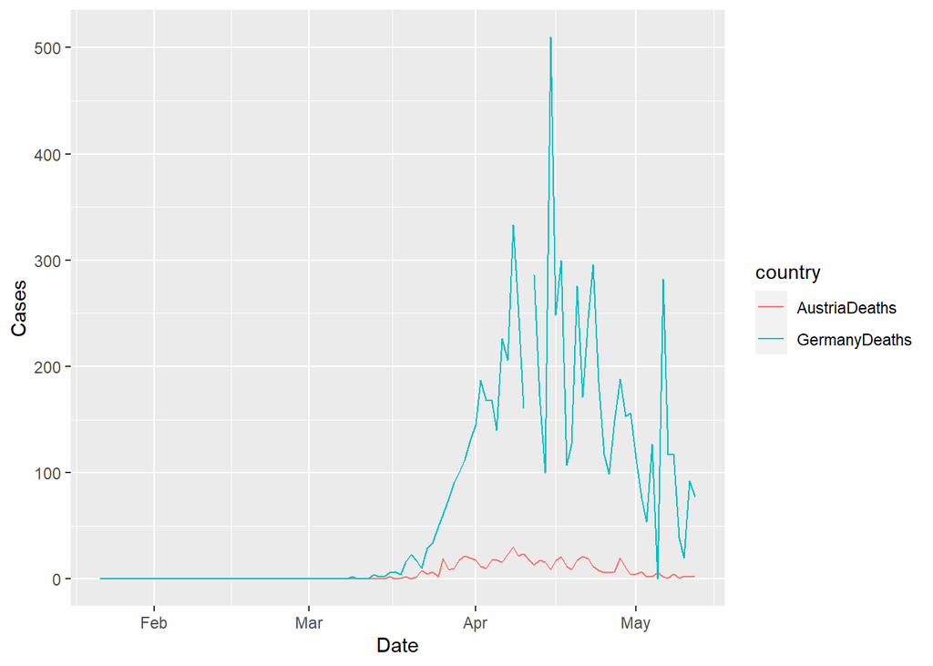

**Figure 09: Time series plot of Death Cases - Germany vs Austria**

In **Figure 09**, When compared with Germany, the total daily death case count in Austria was relatively low.However both Germany and Austria are finally starting to see an overall decline in death cases.

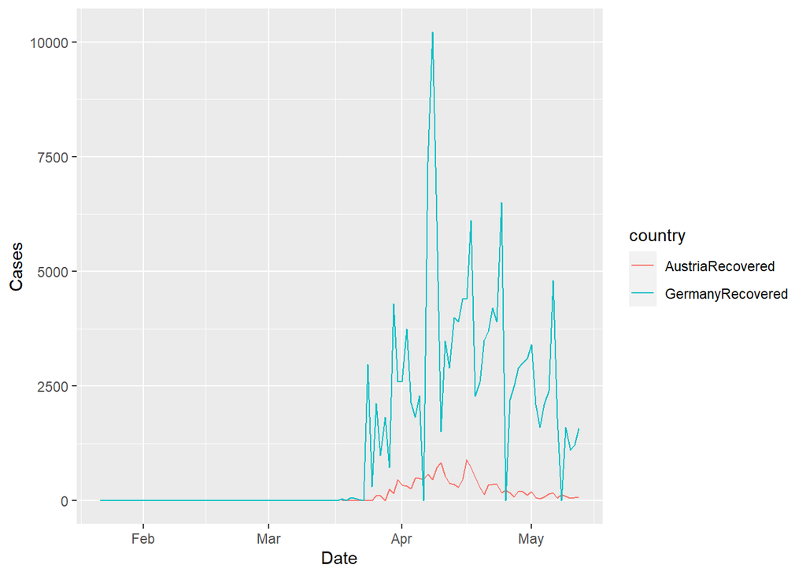

**Figure 10: Time series plot of Recovered Cases - Germany vs Austria**

In **Figure 10**, When compared with Germany, the total daily recovered case count in Austria was relatively low.

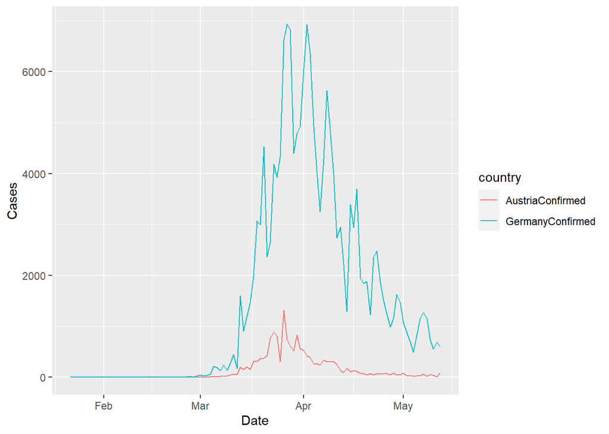

**Figure 11: Time series plot of Confirmed Cases - Germany vs Austria**

In **Figure 11**, When compared with Germany, the total daily confirmed case count in Austria was relatively low. However both Germany and Austria are finally starting to see an overall decline in confirmed cases.

### Since France is a neighbouring country of Germany, Let’s look at Conoravirus spread in France.

## **FRANCE**

```
      date              province           country               lat
 Min.   :2020-01-22   Length:3696        Length:3696        Min.   :-21.135
 1st Qu.:2020-02-18   Class :character   Class :character   1st Qu.:-17.680
 Median :2020-03-17   Mode  :character   Mode  :character   Median : 14.642
 Mean   :2020-03-17                                         Mean   :  8.306
 3rd Qu.:2020-04-14                                         3rd Qu.: 18.071
 Max.   :2020-05-12                                         Max.   : 46.885
      long             type               cases
 Min.   :-63.050   Length:3696        Min.   :-2512.00
 1st Qu.:-61.583   Class :character   1st Qu.:    0.00
 Median :-53.126   Mode  :character   Median :    0.00
 Mean   :  5.429                      Mean   :   71.22
 3rd Qu.: 55.247                      3rd Qu.:    0.00
 Max.   :165.618                      Max.   :26843.00
```

**Table 12: Summary of Coronavirus data - France**

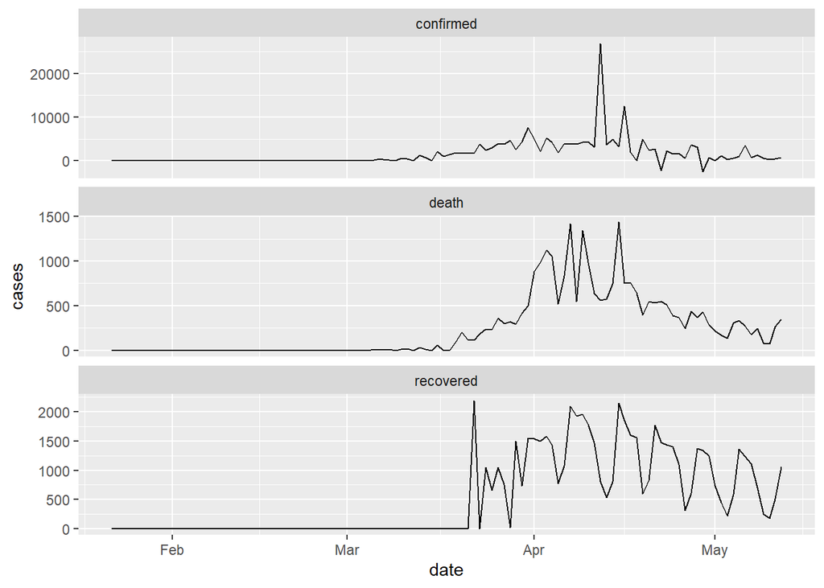

**Figure 12: Time series plot of Coronavirus spread in France**

### Comparing Corona spread- Germany vs France

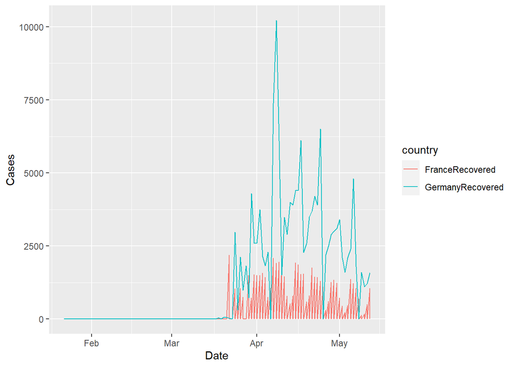

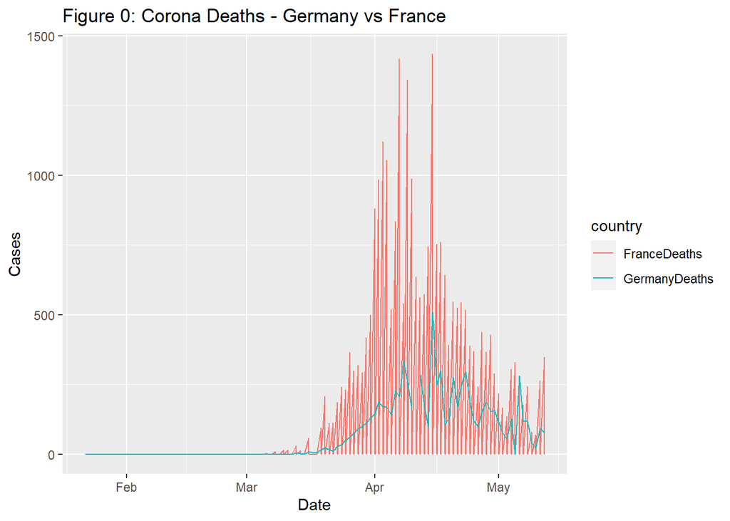

**Figure 14: Time series plot of Death Cases - Germany vs France**

In **Figure 14**, When compared with Germany, the total daily death case count in France was relatively high.However both Germany and France are finally starting to see an overall decline in death cases.

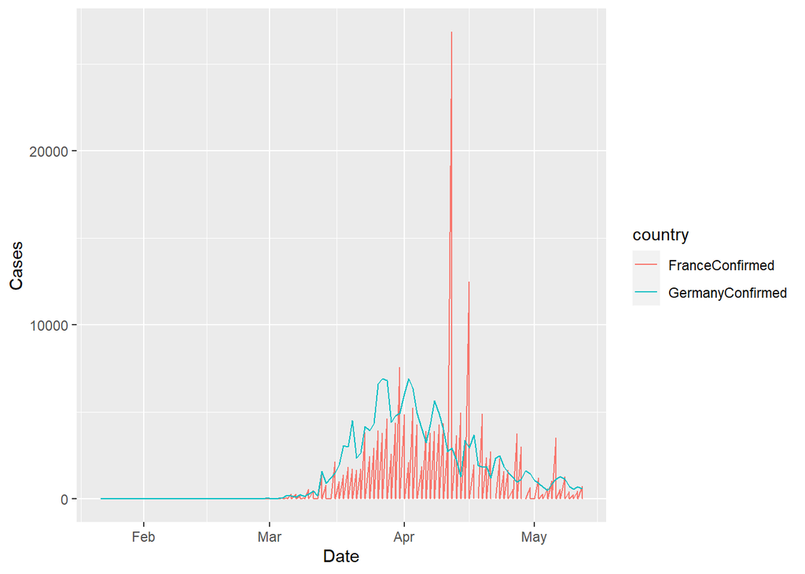

### Since coronavirus continues to be severe in US , Let’s compare with US.

## **US**

```
      date              province           country               lat
 Min.   :2020-01-22   Length:336         Length:336         Min.   :37.09
 1st Qu.:2020-02-18   Class :character   Class :character   1st Qu.:37.09
 Median :2020-03-17   Mode  :character   Mode  :character   Median :37.09
 Mean   :2020-03-17                                         Mean   :37.09
 3rd Qu.:2020-04-14                                         3rd Qu.:37.09
 Max.   :2020-05-12                                         Max.   :37.09
      long            type               cases
 Min.   :-95.71   Length:336         Min.   :-2446
 1st Qu.:-95.71   Class :character   1st Qu.:    0
 Median :-95.71   Mode  :character   Median :   92
 Mean   :-95.71                      Mean   : 5006
 3rd Qu.:-95.71                      3rd Qu.: 2608
 Max.   :-95.71                      Max.   :36188
```

**Table 13: Summary of Coronavirus data - US**

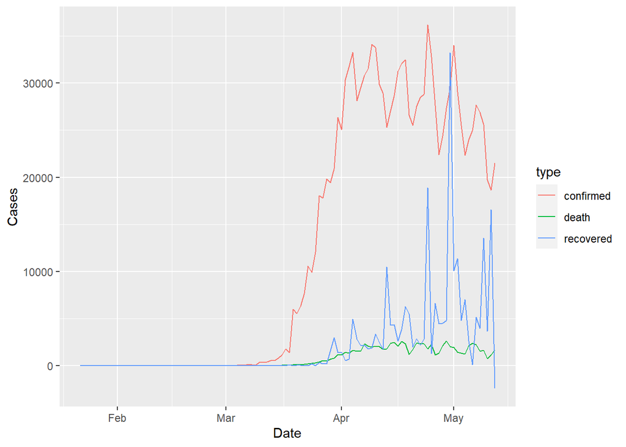

**Figure 16.1: Time series plot of Coronavirus spread in US**

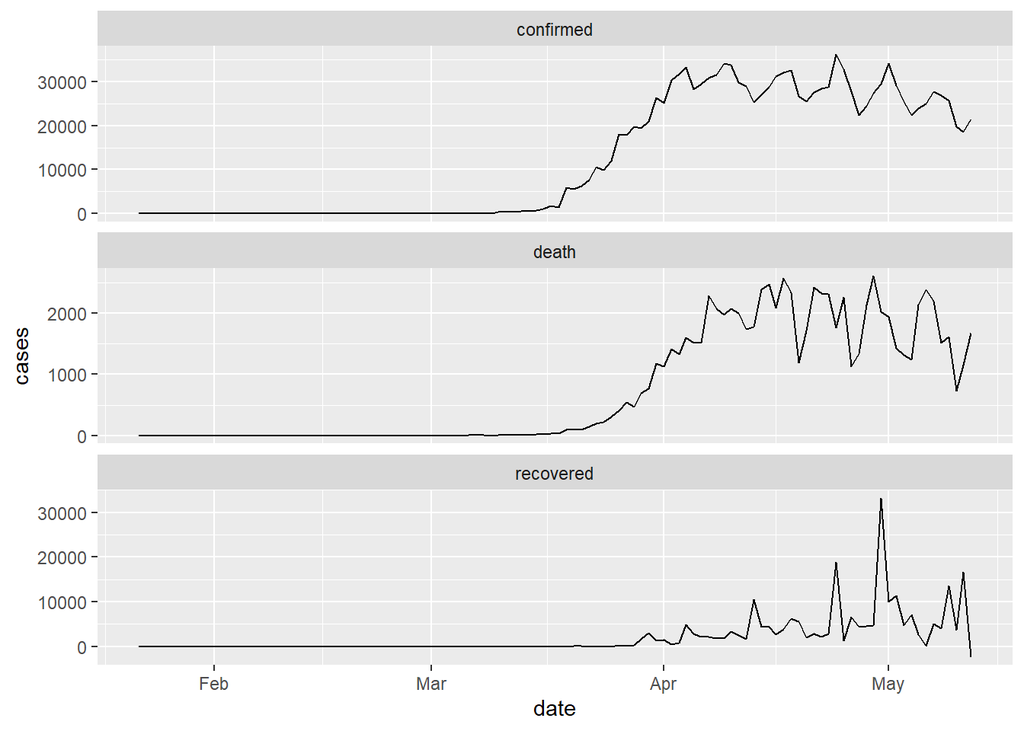

**Figure 16.2: Time series plot of Coronavirus spread in US**

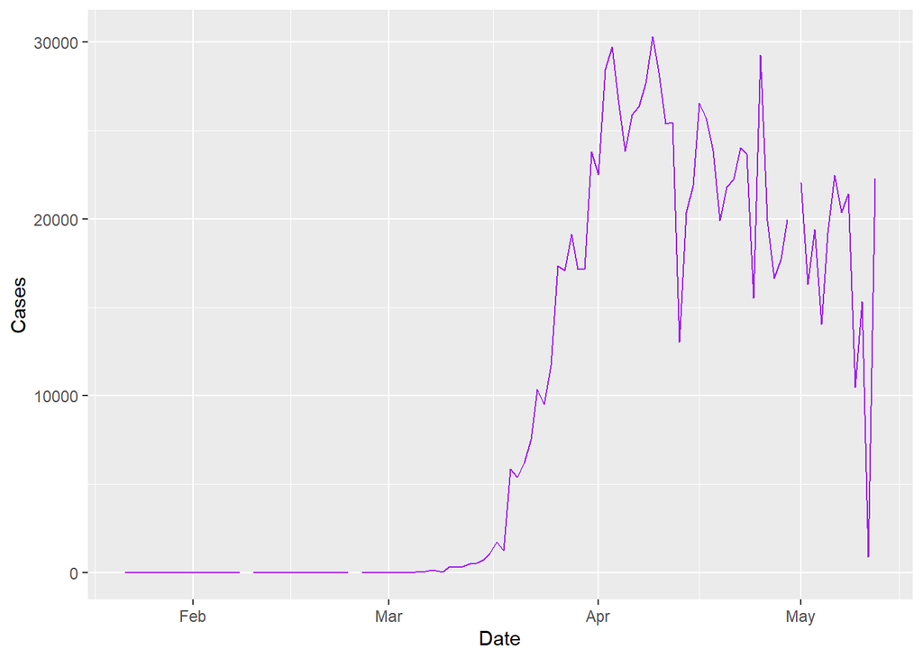

**Figure 17: Time series plot of Active Cases in US (Discontinuity represents missing values/ negative values)**

### Comparing Corona spread- Germany vs US

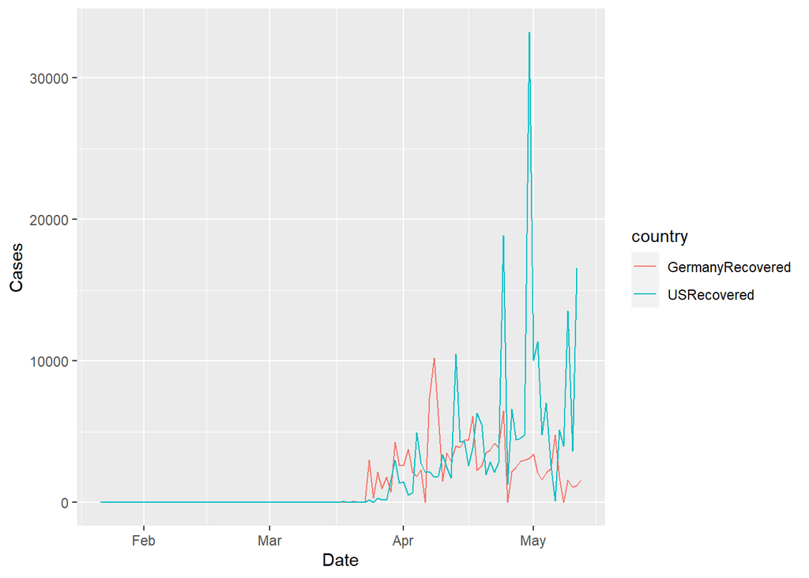

**Figure 18: Time series plot of Recovered Cases - Germany vs US**

In **Figure 18**, When compared with Germany, the total daily recovered case count in US was relatively high.

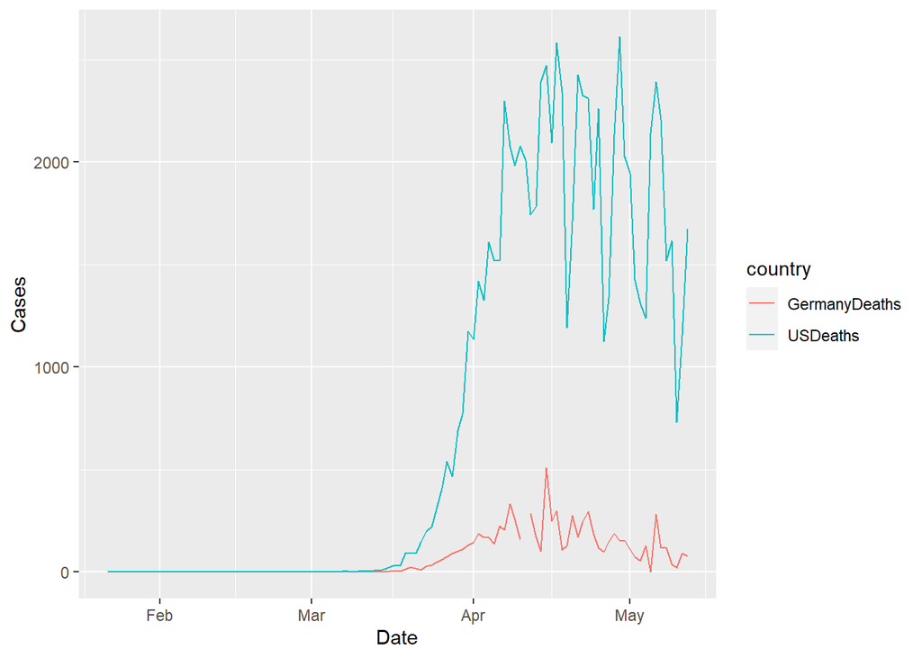

**Figure 19: Time series plot of Death Cases - Germany vs US**

In **Figure 19**, When compared with Germany, the total daily death case count in US was very high.

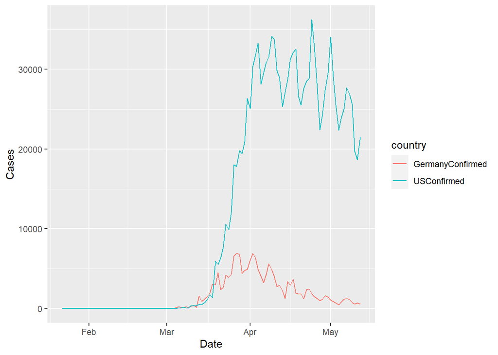

**Figure 20: Time series plot of Confirmed Cases - Germany vs US**

In **Figure 20**, When compared with Germany, the total daily confirmed case count in US was very high.

### Since China is one of the most affected contries in the world, Let’s compare with China.

## **CHINA**

```
      date              province           country               lat
 Min.   :2020-01-22   Length:11088       Length:11088       Min.   :19.20
 1st Qu.:2020-02-18   Class :character   Class :character   1st Qu.:27.61
 Median :2020-03-17   Mode  :character   Mode  :character   Median :31.83
 Mean   :2020-03-17                                         Mean   :32.83
 3rd Qu.:2020-04-14                                         3rd Qu.:37.81
 Max.   :2020-05-12                                         Max.   :47.86
      long            type               cases
 Min.   : 85.24   Length:11088       Min.   : -948.00
 1st Qu.:107.87   Class :character   1st Qu.:    0.00
 Median :113.55   Mode  :character   Median :    0.00
 Mean   :111.65                      Mean   :   15.14
 3rd Qu.:117.32                      3rd Qu.:    1.00
 Max.   :127.76                      Max.   :14840.00
```

**Table 14: Summary of Coronavirus data - China**

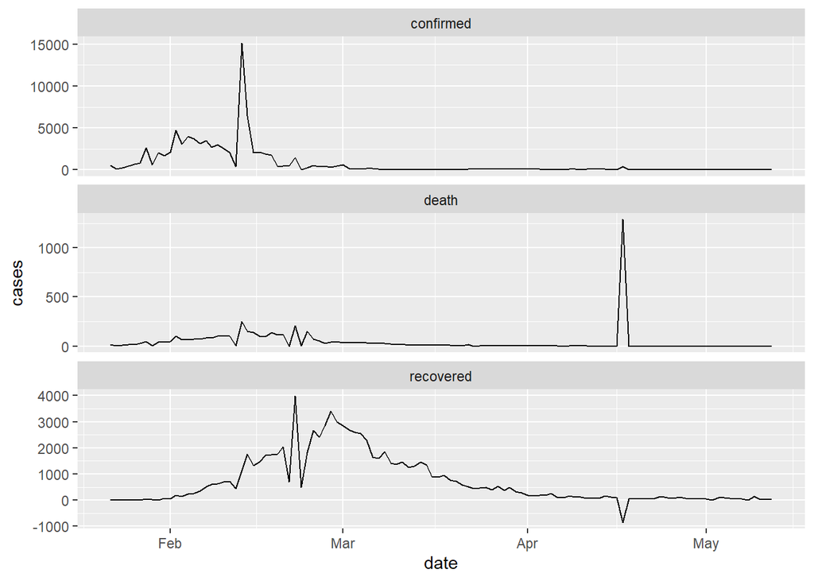

### Comparing Corona spread- Germany vs China

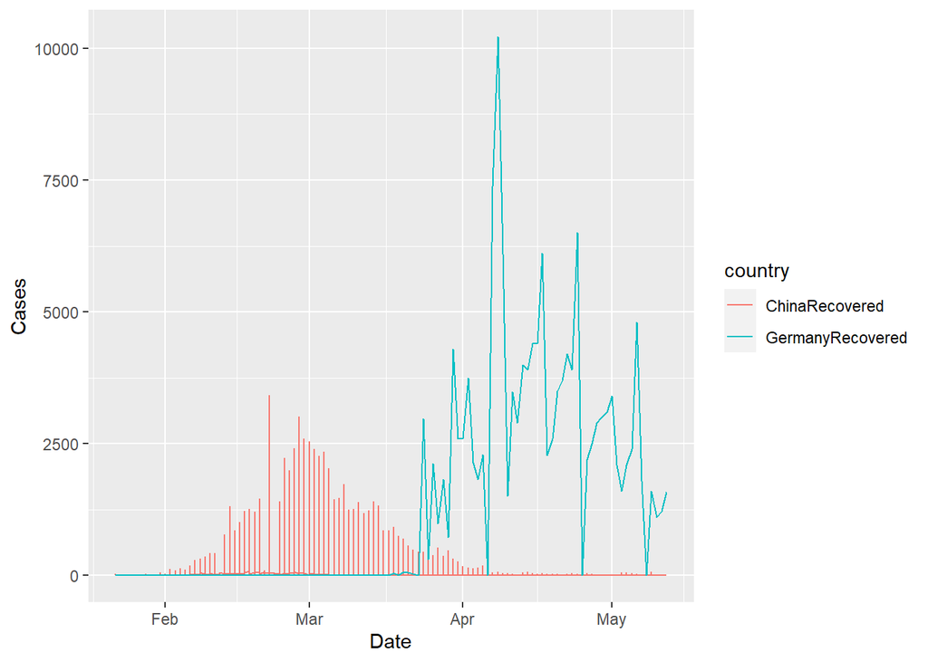

**Figure 21: Time series plot of Recovered Cases - Germany vs China**

In **Figure 21**, China started out with very recovered rate. But from March onwards the recovered rate has fallen stedily.

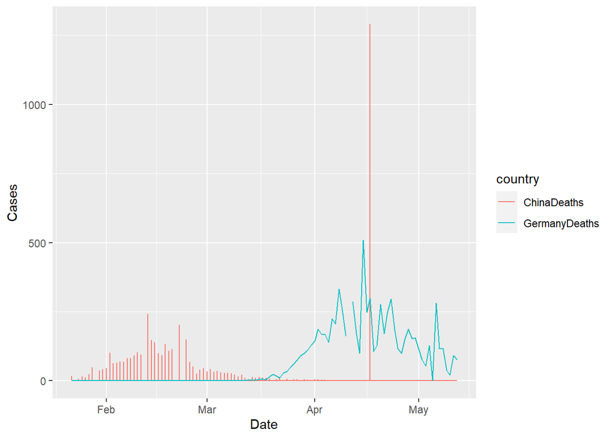

**Figure 22: Time series plot of Death Cases - Germany vs China**

In **Figure 22**, China started out with a very high death rate when compared with Germany and China has managed to reduce it drastically within few months of coronavirus outbreak except very high daily death cases in mid April.

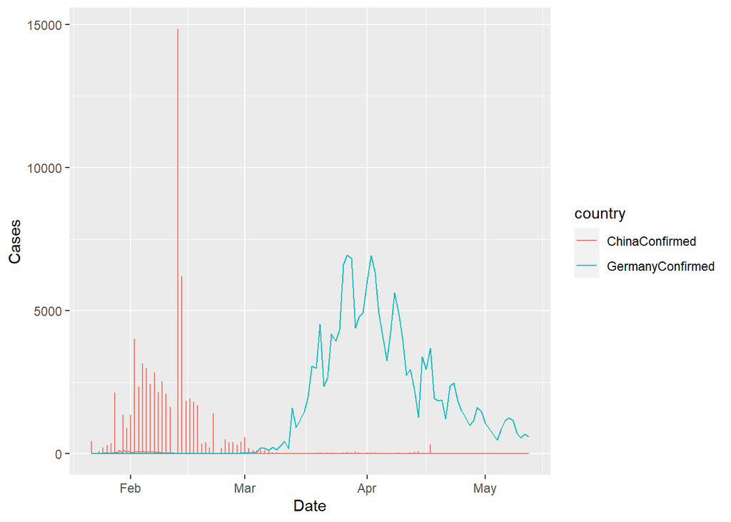

**Figure 23: Time series plot of Confirmed Cases - Germany vs China**

In **Figure 23**, China started out with a very high confirmed rate when compared with Germany and China has managed to reduce it drastically within few months of coronavirus outbreak.

# **CONCLUSION AND DISCUSSION**

# **REFERENCES**

1. @book{10.5555/3086927, author = {Wickham, Hadley and Grolemund, Garrett}, title = {R for Data Science: Import, Tidy, Transform, Visualize, and Model Data}, year = {2017}, isbn = {1491910399}, publisher = {O’Reilly Media, Inc.}, edition = {1st} }

(02)- https://github.com/RamiKrispin/coronavirus

(03)- https://hellor.netlify.app/schedule/R_Markdown